# Assignment 1

The data has been loaded to the variable ‘data’.

First I open and read the data:

```r
setwd('~/coursera/reproducible_research/')
data<-read.csv('activity.csv')
require(ggplot2)
```

#### What is mean total number of steps taken per day?

There are data for 61 days. The total number of steps per day is:

```r
steps_hist<-as.data.frame(cbind(unique(data$date),sapply(unique(data$date),function(x) sum(data$steps[data$date==x],na.rm=T))))
names(steps_hist)<-c('Day','Total_Steps')
print(steps_hist)
```

```
##    Day Total_Steps
## 1    1           0
## 2    2         126
## 3    3       11352
## 4    4       12116
## 5    5       13294
## 6    6       15420
## 7    7       11015
## 8    8           0
## 9    9       12811
## 10  10        9900
## 11  11       10304
## 12  12       17382
## 13  13       12426
## 14  14       15098
```

[output cut: 47 more lines]

And now, the histogram of the total number of steps is:

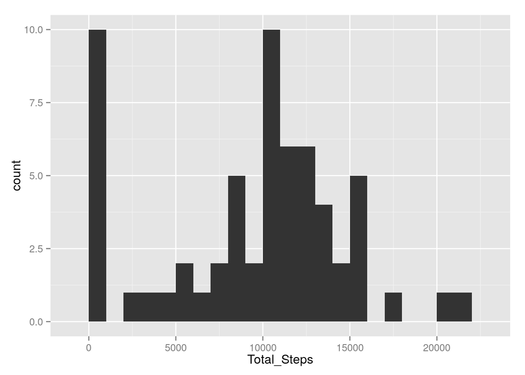

```r
qplot(x=Total_Steps,data=steps_hist,geom='histogram',binwidth=1000)
```

The mean and the median of the total number of steps per day are 9354.2295082 and 10395 steps per day, respectively.

#### What is the average daily activity pattern?

Plotting the average number of steps taken per interval:

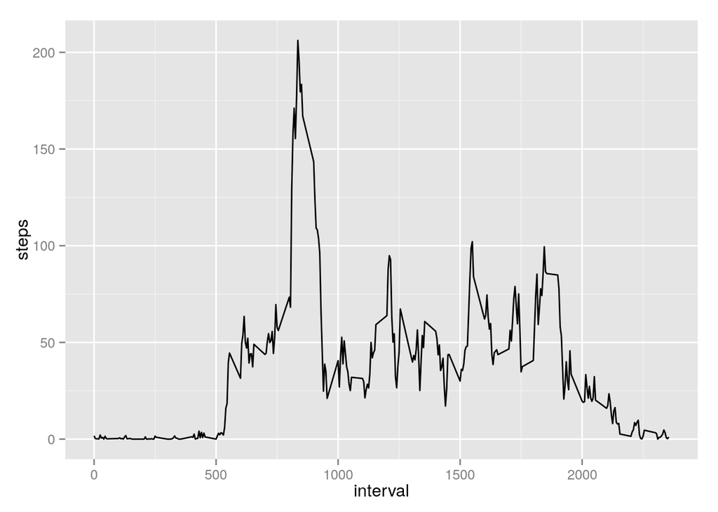

```r
qplot(x=interval,y=steps,data=data,stat='summary',fun.y='mean',geom='line')
```

Now, calculating the 5 minutes interval with the largest average of steps:

```r
interval_steps<-sapply(unique(data$interval),function(x) mean(data$steps[data$interval==x],na.rm=T))
max_step<-which(interval_steps==max(interval_steps))
```

The interval with the maximum number of steps is 835 minutes.

#### Imputing missing values

The number of missing data is:

```r
sum(is.na(data$steps))
```

```
## [1] 2304
```

The missing values will be filled with the average of the interval:

```r
data_filled<-data
missing_vector<-which(is.na(data_filled$steps))
intervals<-unique(data_filled$interval)
data_filled$steps[missing_vector]<-interval_steps[sapply(missing_vector,function(x) which(intervals==data_filled$interval[x]))]
```

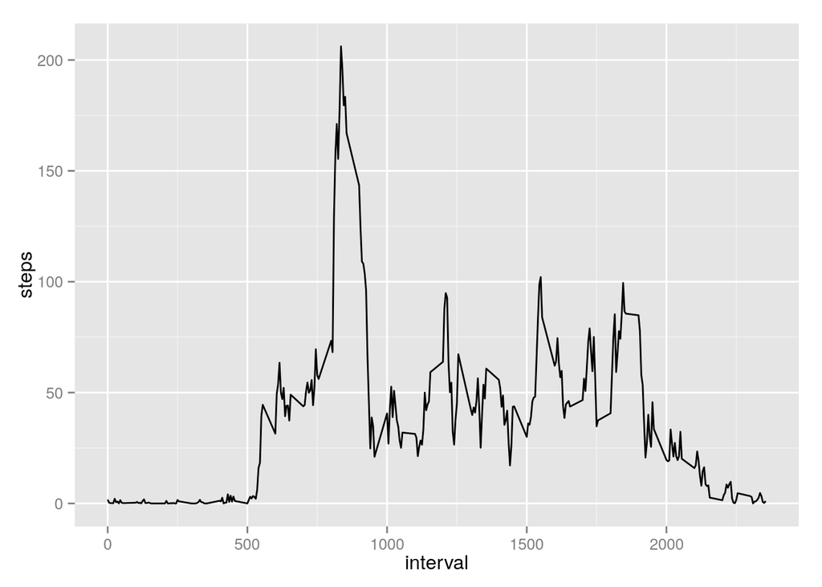

```r
steps_hist_filled<-as.data.frame(cbind(unique(data_filled$date),sapply(unique(data_filled$date),function(x) sum(data_filled$steps[data_filled$date==x],na.rm=T))))
names(steps_hist_filled)<-c('Day','Total_Steps')
qplot(x=interval,y=steps,data=data_filled,stat='summary',fun.y='mean',geom='line')
```

#### Are there differences in activity patterns between weekdays and weekends?

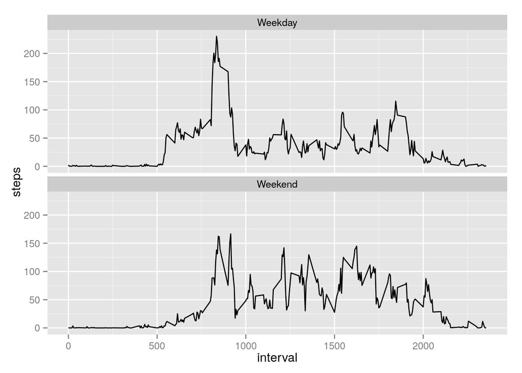

```r
data_filled$weekend<-as.factor(weekdays(as.Date(data_filled$date))=="Saturday"|weekdays(as.Date(data_filled$date))=="Sunday")
levels(data_filled$weekend)<-list(Weekday="FALSE",Weekend="TRUE")
ggplot(data_filled,aes(x=interval,y=steps))+stat_summary(geom='line',fun.y='mean')+facet_wrap(~weekend,ncol=1)
```